# R Beginners Course

Raster files and spatial data

# Objective and contents

## Objective and contents

**Objective**: to learn how to manipulate gridded datasets and vectorised data through the application of the most important functions in R.

- Importing and plotting vector data
- Extract specific spatial information using vector data
- Importing gridded datasets
- Manipulation of gridded datasets
- Exporting gridded datasets in different formats
- Manipulation of values in gridded data

# Importing and plotting vector data

## Vector data

Vector data stores the location, shape, and attributes of geographic features in one of the following forms:

- Points
- Lines
- Polygons

There are different packages that can be used to load and manipulate vector data (shapefles) in R. In this lecture, we will use the **sf** and **terra** packages. The **tibble** package can also be installed as it is used by **sf**.

## Vector data

To install these packages we can use the *install.packages* function.

```r
install.packages("sf")
install.packages("tibble")
install.packages("terra")
```

Once they are installed, we can load them with the *library* function.

```r
library(sf)
library(tibble)
library(terra)
```

## Vector data

To read vector data in R, we can use both packages. To use the **sf** package we can apply the *read_sf*

```r
countries <- read_sf("C:/User/Data/L3_Rasters_and_Shapefiles_Data/Countries")
```

If the folder contains more than one shapefile, you have to specify the file path:

```r
countries <- read_sf("C:/User/Data/L3_Rasters_and_Shapefiles_Data/Countries/Nile_Basin_Countries_GAUL_2014_2.shp")
```

## Vector data

If we type the name of the object in the console:

```r
countries
## Simple feature collection with 15 features and 9 fields
## Geometry type: MULTIPOLYGON
## Dimension:     XY
## Bounding box:  xmin: 12.19545 ymin: -13.45568 xmax: 47.98618 ymax: 31.66734
## Geodetic CRS:  WGS 84
## # A tibble: 15 × 10
##    STATUS           DISP_AREA ADM0_CODE ADM0_NAME STR0_YEAR EXP0_YEAR Shape_Leng
##    <chr>            <chr>         <int> <chr>         <int>     <int>      <dbl>
##  1 Member State     NO              205 Rwanda         1000      3000       8.13
##  2 Member State     NO              133 Kenya          1000      3000      48.5
##  3 Member State     NO               74 South Su…      2011      3000      46.9
##  4 Member State     NO              257 United R…      1000      3000      83.0
##  5 Member State     NO              253 Uganda         1000      3000      23.2
##  6 Sovereignty uns… YES           61013 Ilemi tr…      1000      3000       2.84
##  7 Member State     NO               79 Ethiopia       1000      3000      50.4
##  8 Member State     NO               77 Eritrea        1000      3000      50.0
##  9 Member State     NO               43 Burundi        1000      3000       9.12
## 10 Member State     NO               68 Democrat…      1000      3000      99.0
## 11 Sovereignty uns… YES           40760 Hala'ib …      1000      3000       8.51
## 12 Sovereignty uns… YES           40762 Ma'tan a…      1000      3000       2.06
## 13 Member State     NO                6 Sudan          2011      3000      81.9
## 14 Member State     NO            40765 Egypt          1000      3000      61.3
## 15 Sovereignty uns… YES             102 Abyei          2011      3000       3.61
## # … with 3 more variables: Shape_Area <dbl>, Name_label <chr>,
## #   geometry <MULTIPOLYGON [°]>
```

## Vector data

Let’s plot the countries object:

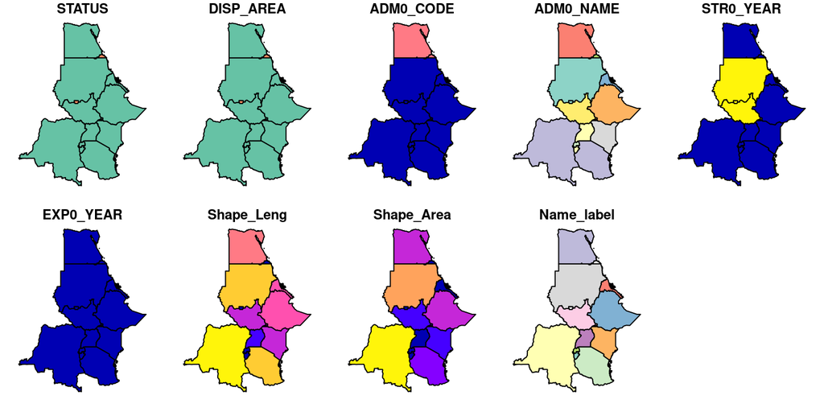

```r
plot(countries)
```

## Vector data

The function names will return the names of all the attributes stored.

```r
names(countries)
```

```
##  [1] "STATUS"     "DISP_AREA"  "ADM0_CODE"  "ADM0_NAME"  "STR0_YEAR"
##  [6] "EXP0_YEAR"  "Shape_Leng" "Shape_Area" "Name_label" "geometry"
```

## Simple Features in R

**sf** objects are data frames with a special “geometry” column:

```r
st_geometry(countries)
## Geometry set for 15 features
## Geometry type: MULTIPOLYGON
## Dimension:     XY
## Bounding box:  xmin: 12.19545 ymin: -13.45568 xmax: 47.98618 ymax: 31.66734
## Geodetic CRS:  WGS 84
## First 5 geometries:
## MULTIPOLYGON (((30.47352 -1.057411, 30.47035 -1...
## MULTIPOLYGON (((39.37656 -4.721247, 39.37412 -4...
## MULTIPOLYGON (((33.02315 12.22673, 33.25586 12....
## MULTIPOLYGON (((40.21717 -10.29314, 40.21717 -1...
## MULTIPOLYGON (((34.09062 3.878785, 34.09114 3.8...
```

## Simple Features in R

Since geometries are not single-valued, they are put in a list-column, with each list element holding the simple feature geometry of that feature. The three classes used to represent simple features are:

- **sf**, the table (data.frame) with feature attributes and feature geometries, which contains
- **sfc**, the list-column with the geometries for each feature (record), which is composed of
- **sfg**, the feature geometry of an individual simple feature

## Simple Features in R

If we want to plot the geometry only:

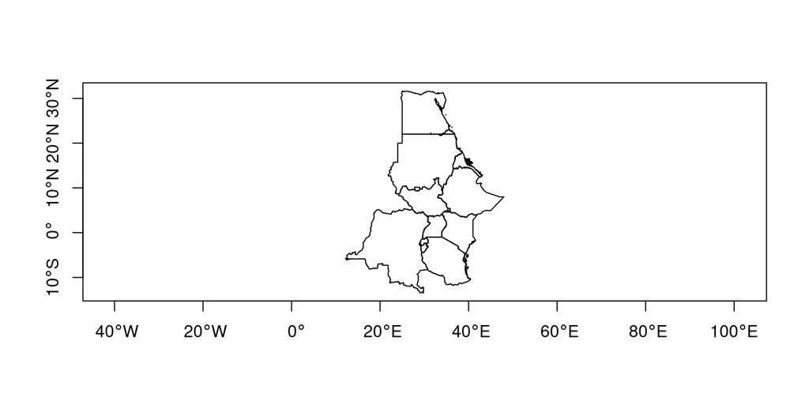

```r
countries_geom <- st_geometry(countries)
plot(countries_geom, axes = TRUE)
```

## Simple Features in R

We can also define the limits for the x-axis and y-axis of the plot.

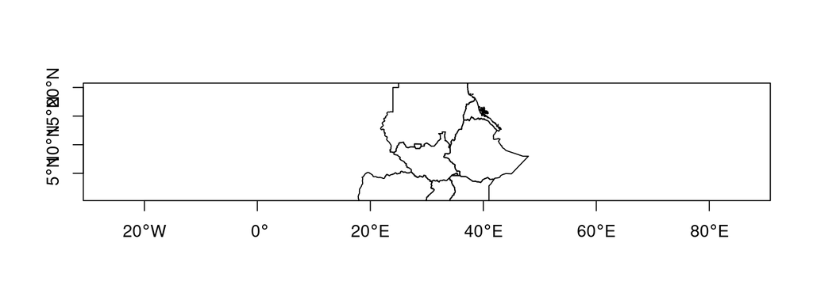

```r
countries_geom <- st_geometry(countries)
plot(st_geometry(countries), axes = TRUE,
xlim = c(20, 40), ylim = c(1, 20))
```

## Simple Features in R

If we want to plot a single attribute:

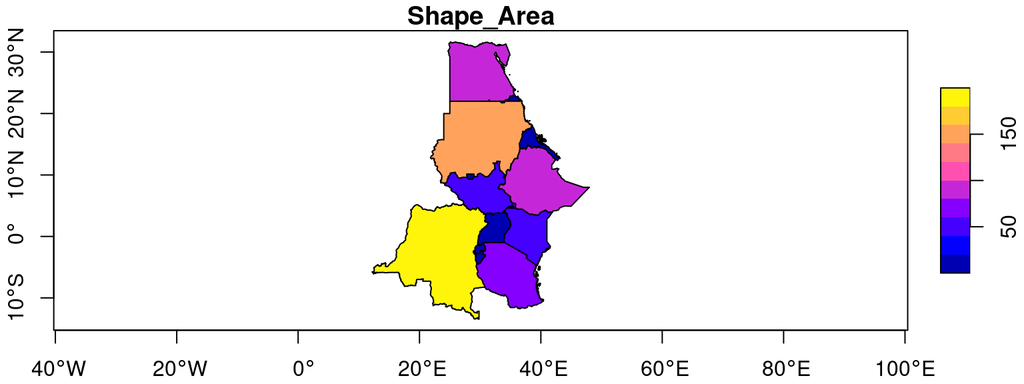

```r
plot(countries["Shape_Area"], axes=TRUE)
```

Many more possibilities: https://r-spatial.github.io/sf/articles/sf5.html

# Extract specific spatial information using vector data

## Extracting Polygons (or Features) from Shapefiles

Every row contains a single feature:

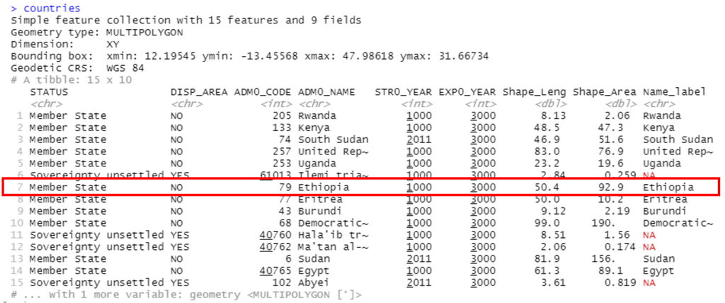

## Extracting Polygons (or Features) from Shapefiles

To get a simple feature containing only Ethopia:

```r
ethiopia <- countries[7, ]
print(ethiopia)
## Simple feature collection with 1 feature and 9 fields
## Geometry type: MULTIPOLYGON
## Dimension:     XY
## Bounding box:  xmin: 32.99994 ymin: 3.401109 xmax: 47.98618 ymax: 14.89416
## Geodetic CRS:  WGS 84
## # A tibble: 1 × 10
##   STATUS DISP_AREA ADM0_CODE ADM0_NAME STR0_YEAR EXP0_YEAR Shape_Leng Shape_Area
##   <chr>  <chr>         <int> <chr>         <int>     <int>      <dbl>      <dbl>
## 1 Membe… NO               79 Ethiopia       1000      3000       50.4       92.9
## # … with 2 more variables: Name_label <chr>, geometry <MULTIPOLYGON [°]>
```

## Extracting Polygons (or Features) from Shapefiles

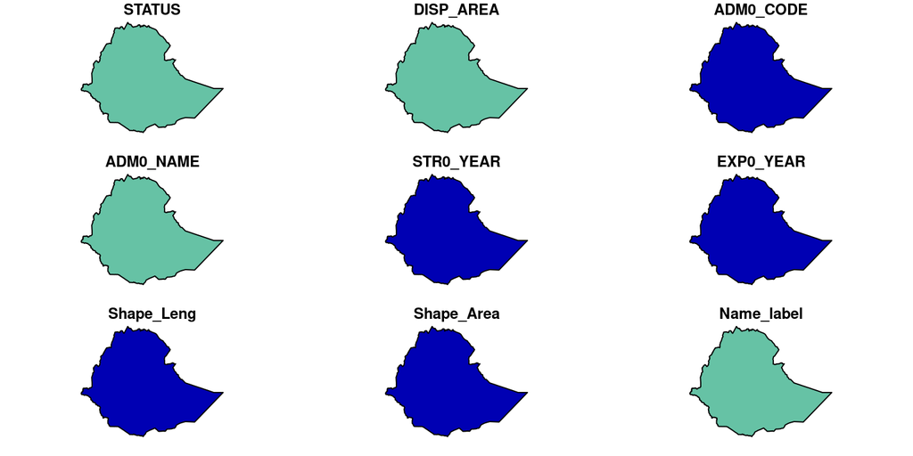

```r
plot(ethiopia)
```

## Reading vector data with the terra package

When we want to manipulate raster and vector data altogether, the **terra** package is very useful. To read vector data with this package we will use the *vect* function.

```r
countries <- vect("C:/User/Data/L3_Rasters_and_Shapefiles_Data/Countries/Nile_Basin_Countries_GAUL2014_2.shp")
```

## Exporting vector data

To save the extracted feature(s) in a specific address on your system, we can use the *write_sf* function.

```r
write_sf(ethiopia, "C:/Users/Ethopida_outline/Ethiopia_outline.shp")
```

You can save into other formats with *st_write*. Look at the driver argument in the help.

## Manipulating attributes

We can get rid of the geometry with the *st_drop_geometry* function. Calculating new attributes (e.g., mm/m2 to total per country):

```r
countries <- read_sf("C:/User/Data/L3_Rasters_and_Shapefiles_Data/Countries")
```

```r
countries["precip_mm"] <- runif(nrow(countries))
countries_df <- st_drop_geometry(countries)
countries["precip_total"] <- countries_df["precip_mm"] * countries_df["Shape_Area"]
```

## Manipulating attributes

Alternatively, we can use **dplyr**:

```r
countries %>%
mutate(precip_ml = runif(nrow(countries)),
precip_total = precip_ml * Shape_Area)
## Simple feature collection with 15 features and 12 fields
## Geometry type: MULTIPOLYGON
## Dimension:     XY
## Bounding box:  xmin: 12.19545 ymin: -13.45568 xmax: 47.98618 ymax: 31.66734
## Geodetic CRS:  WGS 84
## # A tibble: 15 × 13
##    STATUS           DISP_AREA ADM0_CODE ADM0_NAME STR0_YEAR EXP0_YEAR Shape_Leng
##  * <chr>            <chr>         <int> <chr>         <int>     <int>      <dbl>
##  1 Member State     NO              205 Rwanda         1000      3000       8.13
##  2 Member State     NO              133 Kenya          1000      3000      48.5
##  3 Member State     NO               74 South Su…      2011      3000      46.9
##  4 Member State     NO              257 United R…      1000      3000      83.0
##  5 Member State     NO              253 Uganda         1000      3000      23.2
##  6 Sovereignty uns… YES           61013 Ilemi tr…      1000      3000       2.84
##  7 Member State     NO               79 Ethiopia       1000      3000      50.4
##  8 Member State     NO               77 Eritrea        1000      3000      50.0
##  9 Member State     NO               43 Burundi        1000      3000       9.12
## 10 Member State     NO               68 Democrat…      1000      3000      99.0
## 11 Sovereignty uns… YES           40760 Hala'ib …      1000      3000       8.51
## 12 Sovereignty uns… YES           40762 Ma'tan a…      1000      3000       2.06
## 13 Member State     NO                6 Sudan          2011      3000      81.9
## 14 Member State     NO            40765 Egypt          1000      3000      61.3
## 15 Sovereignty uns… YES             102 Abyei          2011      3000       3.61
## # … with 6 more variables: Shape_Area <dbl>, Name_label <chr>,
## #   geometry <MULTIPOLYGON [°]>, precip_mm <dbl>, precip_total <dbl>,
## #   precip_ml <dbl>
```

# Importing gridded datasets

## Raster Files

A raster consists of a matrix of cells (or pixels), where each cell contains a value or set of values representing certain information.

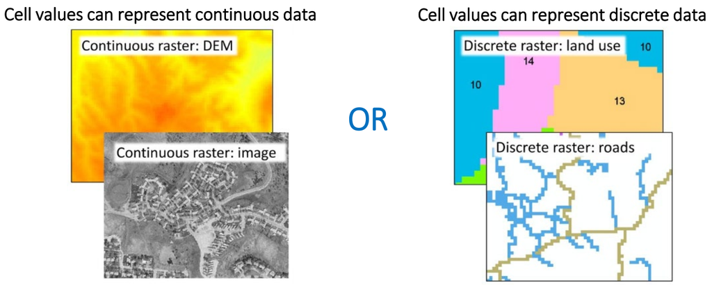

## Raster Files

Rasters with discrete data often use a code to represent different data types.

- For example, these are the values used for the MODIS Land Cover product to represent the IGBP classification (Loveland & Belward, 1997).

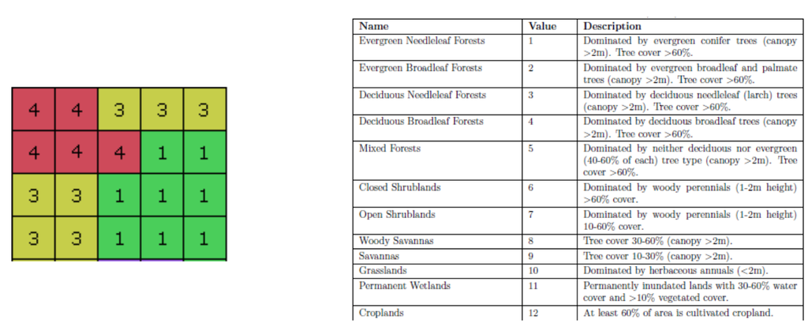

## Import raster files

To open a GeoTIFF raster file (or similar), the *rast* command from the **terra** package is used.

```r
gleam.path <- "C:/User/L3_Rasters_and_Shapefiles_Data/GLEAM_annual/GLEAM_2009.tif"
gleam      <- rast(gleam.path)
```

To be able to perform raster operations, all the raster files involved will need to have the same raster geometry:

- Same spatial extent
- Same spatial resolution
- Same origin

## Raster Files - Coordinate reference system

The metadata of the raster file can be visualised by typing the name of the object where it was stored (in this case gleam).

```r
print(gleam)
## class       : SpatRaster
## dimensions  : 720, 1440, 1  (nrow, ncol, nlyr)
## resolution  : 0.25, 0.25  (x, y)
## extent      : -180, 180, -90, 90  (xmin, xmax, ymin, ymax)
## coord. ref. : lon/lat WGS 84
## source      : GLEAM_2009.tif
## name        : GLEAM_2009
## min value   :  -23.93291
## max value   :   2148.198
```

## Raster Files - Coordinate reference system

```r
crs(gleam)
```

```
## [1] "GEOGCRS[\"WGS 84\",\n    DATUM[\"World Geodetic System 1984\",\n        ELLIPSOID[\"WGS 84\",6378137,298.257223563,\n            LENGTHUNIT[\"metre\",1]],\n        ID[\"EPSG\",6326]],\n    PRIMEM[\"Greenwich\",0,\n        ANGLEUNIT[\"degree\",0.0174532925199433],\n        ID[\"EPSG\",8901]],…
```

```r
crs(gleam) <- "+proj=longlat +datum=WGS84 +no_defs +ellps=WGS84
+towgs84=0,0,0"
```

## Raster Files - Plotting a raster

To plot a raster we use the *plot* function.

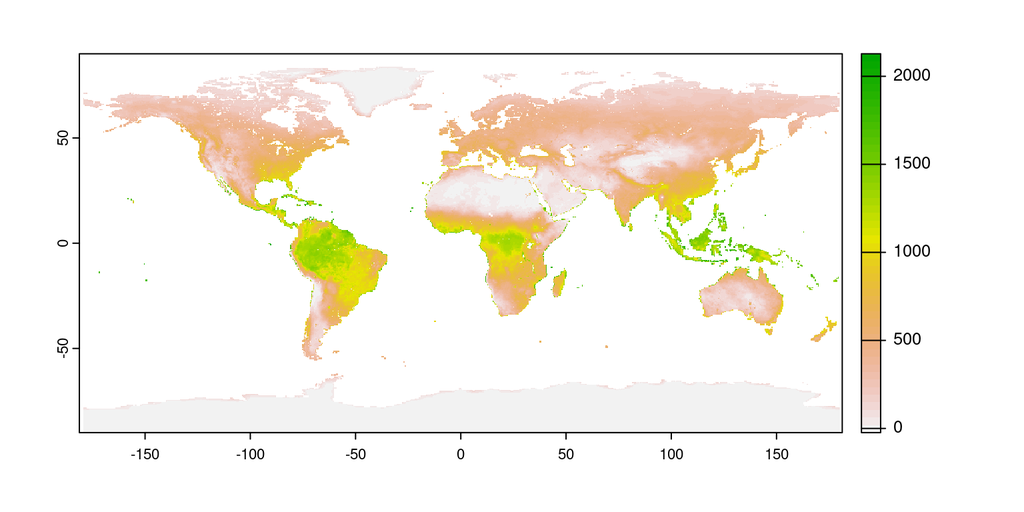

```r
plot(gleam)
```

## Raster Files - Plotting a raster

Alternatively, we can use the function click to get the value of a certain pixel.

```r
click(gleam)
```

To exit the click function please press **Esc**.

## Raster Files

The package **terra** is able to work efficiently with a large number of raster files; therefore, Creating a multi-layer objects is extremely easy.

The use of multi-layered gridded objects (stacks) is very useful in multiple cases (e.g., when working with rasters concerning environmental data such as precipitation, evapotranspiration and temperature).

## Creating a multi-layered gridded object

We want to use these annual ETa files to:

- Create a stack with all annual files
- Calculate a multi-annual mean Ea raster

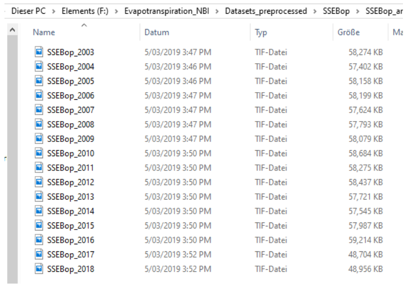

# Manipulation of gridded datasets

## Manupulating a Raster Stack - Example

**Step 1:** List all the files within the folder.

```r
ssebop.path <- "C:/Users/Example/SSEBop_annual"
ssebop.files <- list.files(ssebop.path, full.names = TRUE, pattern = ".tif")
```

```r
head(ssebop.files)
```

[output not shown]

## Manupulating a Raster Stack - Example

**Step 2:** Create a stack from all the single raster layers.

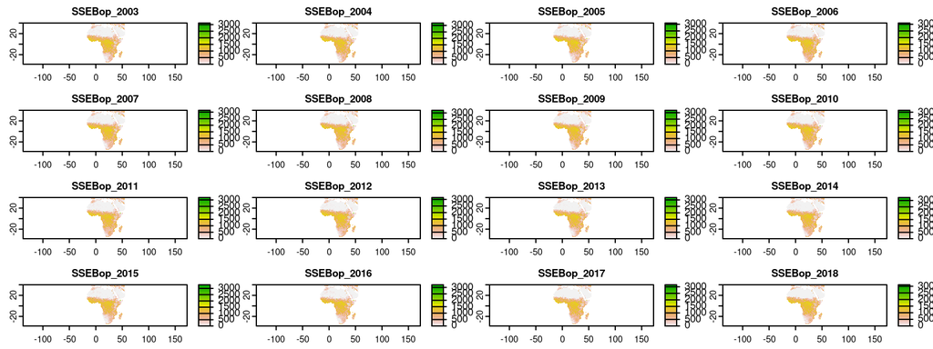

```r
ssebop <- rast(ssebop.files)
plot(ssebop)
```

## Manupulating a Raster Stack - Example

Note: similar to with other data formats, we can use the function names to look at the names of the layers.

## Manupulating a Raster Stack - Example

**Step 3:** Calculate the multi-annual mean.

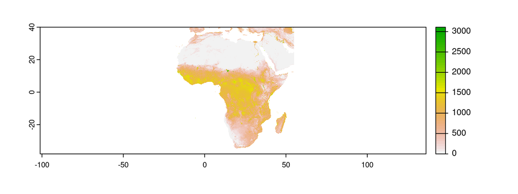

```r
ssebop.multiannual <- mean(ssebop)
plot(ssebop.multiannual)
```

## Accessing Rasters from a Raster Stack

We currently have the raster stack saved as the object ssebop.

```r
print(ssebop)
## class       : SpatRaster
## dimensions  : 8082, 7772, 16  (nrow, ncol, nlyr)
## resolution  : 0.009652, 0.009652  (x, y)
## extent      : -20.00845, 55.00689, -38.00535, 40.00211  (xmin, xmax, ymin, ymax)
## coord. ref. : lon/lat WGS 84 (EPSG:4326)
## sources     : SSEBop_2003.tif
##               SSEBop_2004.tif
##               SSEBop_2005.tif
##               ... and 13 more source(s)
## names       : SSEBop_2003, SSEBop_2004, SSEBop_2005, SSEBop_2006, SSEBop_2007, SSEBop_2008, ...
## min values  :           0,           0,           0,           0,           0,           0, ...
## max values  :        3272,        3353,        3299,        3296,        3462,        3333, ...
```

## Accessing Rasters from a Raster Stack

Similar to a list, we use double square brackets to access a particular raster (or multiple rasters) from a raster stack.

```r
print(ssebop[[2]])
## class       : SpatRaster
## dimensions  : 8082, 7772, 1  (nrow, ncol, nlyr)
## resolution  : 0.009652, 0.009652  (x, y)
## extent      : -20.00845, 55.00689, -38.00535, 40.00211  (xmin, xmax, ymin, ymax)
## coord. ref. : lon/lat WGS 84 (EPSG:4326)
## source      : SSEBop_2004.tif
## name        : SSEBop_2004
## min value   :           0
## max value   :        3353
print(ssebop[[1:3]])
## class       : SpatRaster
## dimensions  : 8082, 7772, 3  (nrow, ncol, nlyr)
## resolution  : 0.009652, 0.009652  (x, y)
## extent      : -20.00845, 55.00689, -38.00535, 40.00211  (xmin, xmax, ymin, ymax)
## coord. ref. : lon/lat WGS 84 (EPSG:4326)
## sources     : SSEBop_2003.tif
##               SSEBop_2004.tif
##               SSEBop_2005.tif
## names       : SSEBop_2003, SSEBop_2004, SSEBop_2005
## min values  :           0,           0,           0
## max values  :        3272,        3353,        3299
```

## Cropping and Masking Rasters

- Cropping a raster (crop function) will extract the part of a raster within that rectangular area.
- Masking a raster (mask function), will extract the pixels within the shapefile.

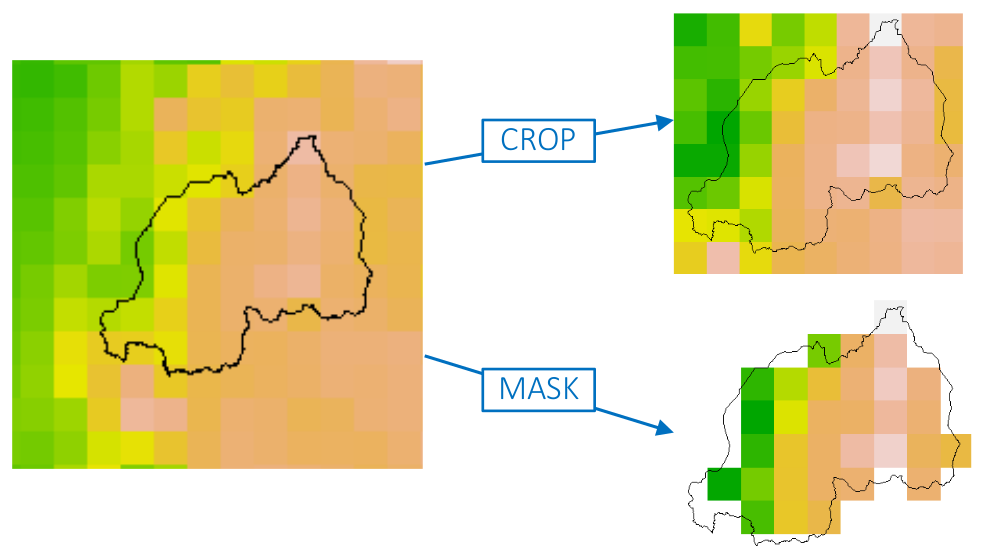

## Crop Function

The crop function extracts a portion of a gridded dataset according to a selected input (can be a raster or a vector file; i.e., SpatRaster and SpatVector, respectively).

To crop a raster:

```r
rwanda     <- countries[1, ]
rwanda     <- vect(rwanda)
gleam.crop <- crop(gleam, rwanda)
```

## Crop Function

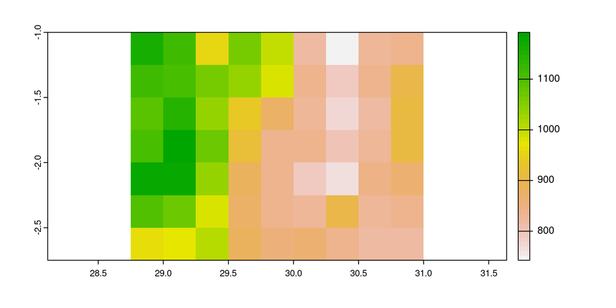

```r
plot(gleam.crop)
```

## Crop function

The parameter snap is used to align the cropped file to the extent of the selected element that is used to perform the crop.

- “near” (default)
- “in”
- “out”

```r
gleam.crop <- crop(gleam, rwanda, snap = "out")
```

## Crop function

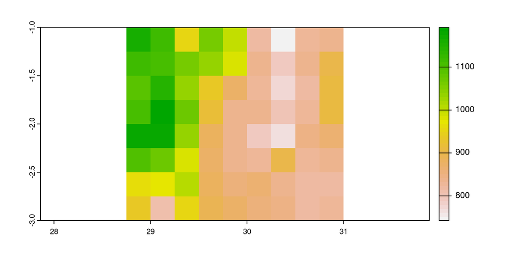

```r
plot(gleam.crop)
```

## Mask function

To mask a raster:

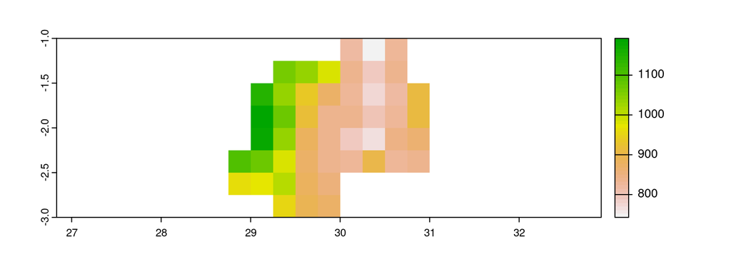

```r
gleam.mask <- mask(gleam.crop, rwanda)
plot(gleam.mask)
```

## What Values are in my Raster?

```r
gleam_vals <- values(gleam.mask)
gleam_vals <- as.numeric(gleam_vals)
print(gleam_vals)
```

```
##  [1]        NA        NA        NA        NA        NA  823.3318  742.6441
##  [8]  824.1913        NA        NA        NA 1063.5068 1031.8060  977.4069
## [15]  837.3028  793.3273  835.6875        NA        NA 1141.6630 1031.7339
## [22]  938.8115  869.1260  827.8035  774.6710  820.8055  905.7816        NA
## [29] 1192.4106 1073.8735  914.8868  840.9797  838.4015  800.3232  828.6646
## [36]  908.3577        NA 1179.2241 1033.6238  878.3455  838.2838  795.3875
## [43]  769.3068  844.0502  860.8229 1094.2697 1071.3359  979.1405  876.9600
## [50]  837.6367  830.4340  897.6795  830.6163  840.5397  966.6479  974.6377
## [57] 1011.7329  880.3939  856.8268        NA        NA        NA        NA
## [64]        NA        NA  957.3956  891.5947  873.2820        NA        NA
## [71]        NA        NA
```

## Resample rasters

In order to perform raster operations, the raster geometry between the layers must be the same.

- A raster layer can be resampled using multiple methods.
- Here we focus on two: bilinear interpolation and nearest neighbour interpolation.

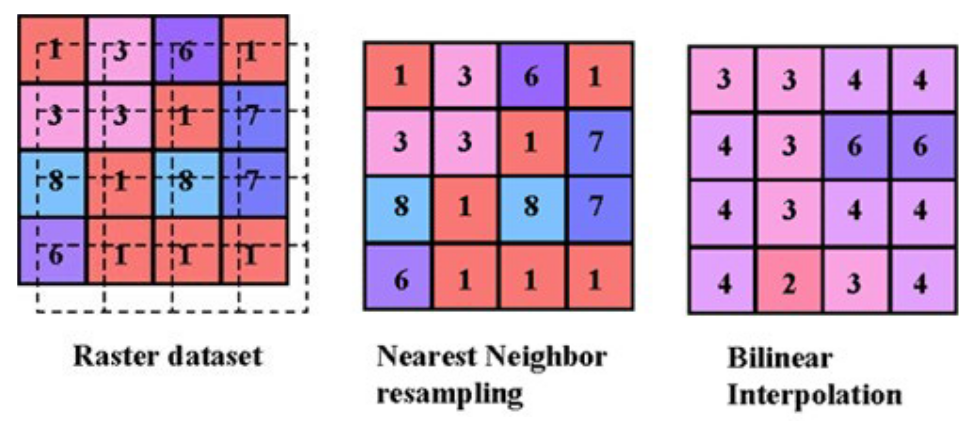

## Resample rasters

The previous slide showed resampling to a different origin using the same grid-cell size.

- Resampling can also be used to change the spatial resolution of the raster layer.

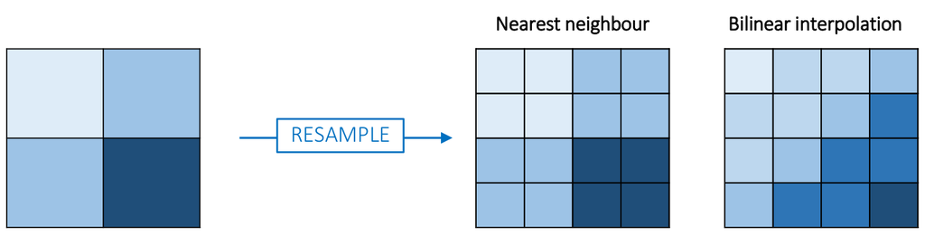

## Resample rasters

How to resample rasters in R. - Nearest neighbour method (rasters with categorical or continous variables)

```r
land.cover <- "C:/Users/Example/MCD12Q1_LC1_2009_001.tif"
land.cover <- rast(land.cover)
```

```r
print(land.cover)
## class       : SpatRaster
## dimensions  : 6002, 4802, 1  (nrow, ncol, nlyr)
## resolution  : 0.008329863, 0.008330556  (x, y)
## extent      : 10, 50, -15, 35  (xmin, xmax, ymin, ymax)
## coord. ref. : lon/lat WGS 84 (EPSG:4326)
## source      : MCD12Q1_LC1_2009_001.tif
## name        : MCD12Q1_LC1_2009_001
## min value   :                    1
## max value   :                   17
```

## Resample rasters

To resample the raster to the spatial resolution of the **gleam** object we will use the *resample* function.

```r
landcover.res <- resample(land.cover, gleam, method = "ngb")
```

## Resample rasters

```r
print(landcover.res)
## class       : SpatRaster
## dimensions  : 720, 1440, 1  (nrow, ncol, nlyr)
## resolution  : 0.25, 0.25  (x, y)
## extent      : -180, 180, -90, 90  (xmin, xmax, ymin, ymax)
## coord. ref. : +proj=longlat +ellps=WGS84 +towgs84=0,0,0,0,0,0,0 +no_defs
## source      : memory
## name        : MCD12Q1_LC1_2009_001
## min value   :                    2
## max value   :                   17
```

## Resample rasters

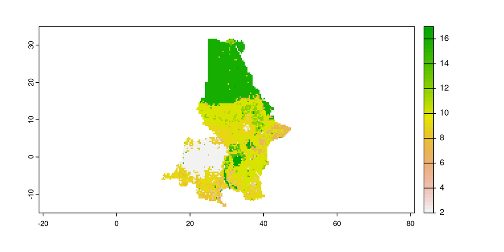

```r
plot(landcover.res, xlim = c(10, 50), ylim = c(-15, 35))
```

## Resample rasters

How to resample rasters in R. Bilinear method (rasters with continuous variables).

```r
chirps <- "C:/Users/Example/chirps_monthly2009-01"
chirps <- rast(chirps)
```

```r
print(chirps)
## class       : SpatRaster
## dimensions  : 2000, 7200, 1  (nrow, ncol, nlyr)
## resolution  : 0.05, 0.05  (x, y)
## extent      : -180, 180, -50, 50  (xmin, xmax, ymin, ymax)
## coord. ref. : lon/lat WGS 84 (EPSG:4326)
## source      : chirps_monthly2009-01.tif
## name        : chirps_monthly2009-01
## min value   :                     0
## max value   :              1301.122
chirps.res <- resample(chirps, gleam, method = "bilinear")
```

## Resample rasters

```r
print(chirps.res)
## class       : SpatRaster
## dimensions  : 720, 1440, 1  (nrow, ncol, nlyr)
## resolution  : 0.25, 0.25  (x, y)
## extent      : -180, 180, -90, 90  (xmin, xmax, ymin, ymax)
## coord. ref. : +proj=longlat +ellps=WGS84 +towgs84=0,0,0,0,0,0,0 +no_defs
## source      : memory
## name        : chirps_monthly2009-01
## min value   :                     0
## max value   :              1221.876
```

## Resample rasters

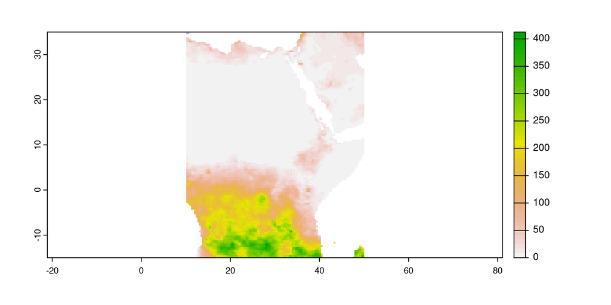

```r
plot(chirps.res, xlim = c(10, 50), ylim = c(-15, 35))
```

# Exporting gridded datasets

After we have altered a raster, we may want to save the new raster. This can be done with the *writeRaster* function (part of the **terra** package).

```r
writeRaster (x, filename, overwrite, ...)
```

**x:** raster object. **filename:** output filename (with complete file path). **overwrite:** logical.

## Exporting gridded datasets

Let’s use the *writeRaster* function to save the resampled CHIRPS raster from the last exercise. We will save the raster as a GeoTiff file.

```r
writeRaster(chirps.res, "add file path", datatype = "INT1U", overwrite = TRUE)
```

Question: How could you make the file path name change according to the value of a variable?

# Manipulation of values in gridded data

## Raster Operations

Once rasters have the same geometry, it is easy to perform mathematical operations. - Example - If we have the following three rasters:

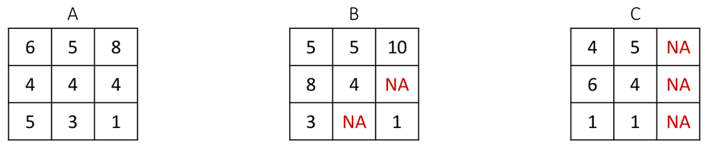

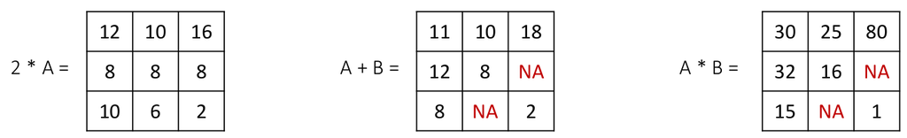

## Raster Operations - NA values

Now, if we have these rasters in a stack:

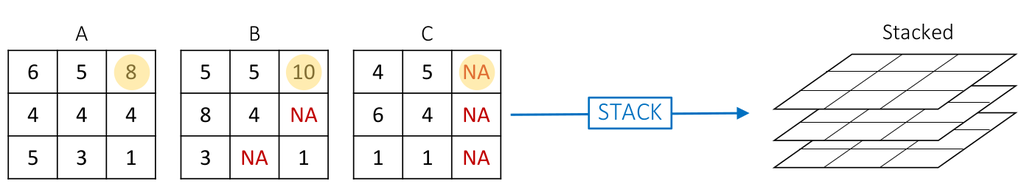

What would be the result of the following expressions for the highlighted grid-cell:

- mean(stacked, na.rm = TRUE)
- mean(stacked, na.rm = FALSE)

## Isolating Cells with Particular Attributes

We can identify the grid-cells with certain attributes. For example, the regions where more than 200 mm of precipitation fell during January, 2009.

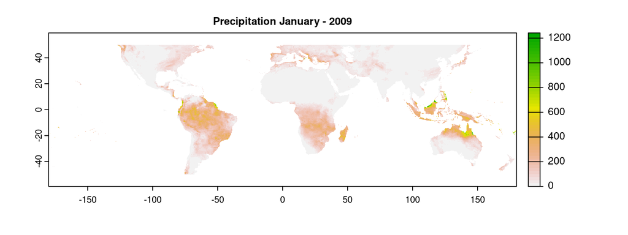

```r
plot(chirps, main = "Precipitation January - 2009")
```

## Isolating Cells with Particular Attributes

For this purpose, we will set the values higher than 200 mm to equal 1 , while the values lower or equal to 200 mm will be set to a value of 0.

```r
chirps.lim <- chirps
chirps.lim[chirps.lim <= 200] <- 0
chirps.lim[chirps.lim > 200]  <- 1
```

## Isolating Cells with Particular Attributes

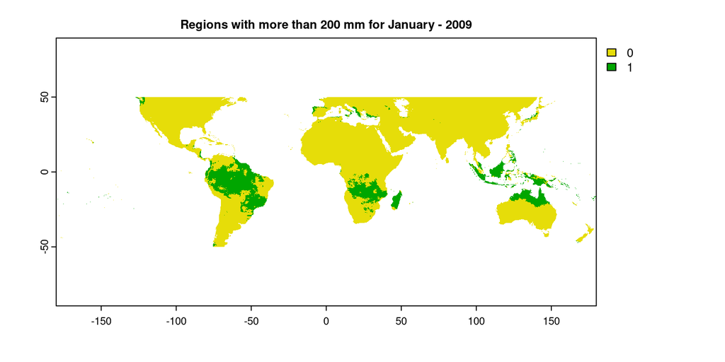

```r
plot(chirps.lim, main = "Regions with more than 200 mm for January - 2009")
```

## Isolating Cells with Particular Attributes

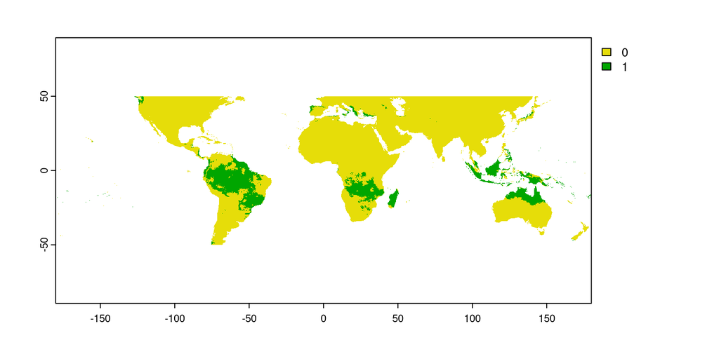

```r
plot(chirps.lim)
```

## Isolating Cells with Particular Attributes

Another common use of this function is to create a raster where values are either 1 or NA (hereafter, we will call this a “unitary” raster). In this example, we want to calculate the average precipitation for January 2009 in the Nile Basin countries over the Arid region of the Köppen-Geiger major climate zones.

```r
climate.zones <- "C:/Users/Example/NB_Major_CZ.tif"
climate.zones <- rast(climate.zones)
```